# Exercise 10

Chenwei Xiao

2020/11/18

For this exercise your task is to create 3 neural network models and to compare their performance. The provided data contains 2 classes (0 and 1). Our aim is to compare those models using the majority of the metrics we have seen in tutorial 10.

Tasks:

1. Read in the data.
2. Visualize the data and print the proportion of data belonging to each class.
3. Split into training and test set using Stratified split.
4. Create 3 different neural network models of your taste ranging from a simple to a very complex one.
5. For each model calculate accuracy, presicion, recall and f-score on the test data.
6. For each model plot the desicions on the test data.
7. For the best performing model make the ROC curve and calculate the corresponding AUC.
8. Train the best performing model 5 times. For each time calculate the probability output on the test data. Average the probabilities over the 5 models and then make decisions. Print accuracy, presicion, recall and f-score on the test data.

The required libraries and some useful functions are already imported in the following chunks. For the ROC curve you can also use the `pROC` package.

### Import libraries

```r
library(tidyverse)
library(gridExtra)
library(reticulate)
library(pROC)
```

```r
use_condaenv()
library(keras)
library(rsample)

options(repr.plot.width = 10, repr.plot.height = 7)
```

### Import functions

```r
#Area Under Curve
simple_auc <- function(x, y){
  #Revert order
  x = rev(x)
  y = rev(y)
  #Define rectangles, calculate area and add those
  dx <- c(diff(x), 0)
  dy <- c(diff(y), 0)
  sum(y * dx) + sum(dy * dx)/2
}

#ROC CURVE
ROC = function(fpr, recall, viz = T){

    #Calculate the area under the ROC
    auc = simple_auc(fpr,recall)

    #Visualize the ROC
    if (viz){

        x = seq(0,1,length.out = 100)
        g = ggplot() +
        geom_line(aes(x = fpr, y = recall,color='Model') , lty =2,lwd = 1.2)+
        geom_line(aes(x=x,y=x,color = 'Baseline'),inherit.aes = F,lty=2,alpha=0.8)+
        labs(x = 'False Positive Rate',
             y = 'Recall',
             color='',
             title='Area Under The curve ROC',
            subtitle=paste("AUC : ",round(auc,2)))+
        theme_grey(base_size = 20)
    }
    else{
        g = NA
    }

    return (list(plot = g,value = auc))
}

confusion = function(y_true, pred_out, threshold = 0.5, verbose = T){

  true_positives = sum((pred_out >= threshold) & (y_true == 1))
  true_negatives = sum((pred_out < threshold) & (y_true == 0))
  false_positives = sum((pred_out >= threshold) & (y_true == 0))
  false_negatives = sum((pred_out < threshold) & (y_true == 1))

  if (verbose) {
    cat('true positives: ',true_positives,'\n')
    cat('true negatives: ',true_negatives,'\n')
    cat('false positives: ',false_positives,'\n')
    cat('false negatives: ',false_negatives,'\n')
  }
  return (list(tp = true_positives, tn = true_negatives, fp = false_positives, fn = false_negatives))
}

precision_and_recall = function(true_positives, true_negatives,false_positives, false_negatives, verbose=T){

  #Protect against division by zero
  if ((true_positives + false_positives) > 0){
    precision = true_positives /(true_positives + false_positives)
  }
  else{
    precision = 1
  }

  if ((true_positives + false_negatives) > 0){
    recall = true_positives / (true_positives + false_negatives)
  }
  else{
      recall = 0
  }

  if (verbose){
    cat("Precision: " ,precision,"\n")
    cat("Recall: ",recall,"\n")
  }

  return (list(precision = precision, recall = recall))
}

f_score = function(precision,recall,verbose=T){

    #Calculate F
    f = 2*precision*recall/(precision+recall)

    #If the user has requested verbose output, provide it
    if(verbose){
        cat("F-score: ",f,"\n")
    }

    #Return F
    return(f)
}
```

IMPORTANT NOTE: READ CAREFULLY!

Do not skip this part or you’ll run into issues later on! In a moment, after you’ve read the following instructions carefully, you should: - run the code chunk immediately below this text (`keras_model_sequential()`). - look down in the *Console* it asks if you want to install some packages: (“Would you like to install Miniconda? [Y/n]:”). - write *n* and press enter. You should see the following code in the console: `Would you like to install Miniconda? [Y/n]: n`. Now, you can normally continue with the exercise.

If you were too eager and already pressed *Y* (yes) and enter, don’t panic! Just close your environment, re-open it and make sure that next time you go with *n* (no).

```r
keras_model_sequential()
```

### Read in the data

```r
df_data <- read_csv(file = '../../data/exercise/data.csv')
df_data %>% head()
```

```
## # A tibble: 6 x 3
##      x1     x2     y
##   <dbl>  <dbl> <dbl>
## 1 0.213 0.513      1
## 2 0.971 0.238      1
## 3 0.578 0.437      1
## 4 0.142 0.281      0
## 5 0.842 0.572      0
## 6 0.962 0.0181     1
```

### Visualize data and print proportion of data belongs to each class.

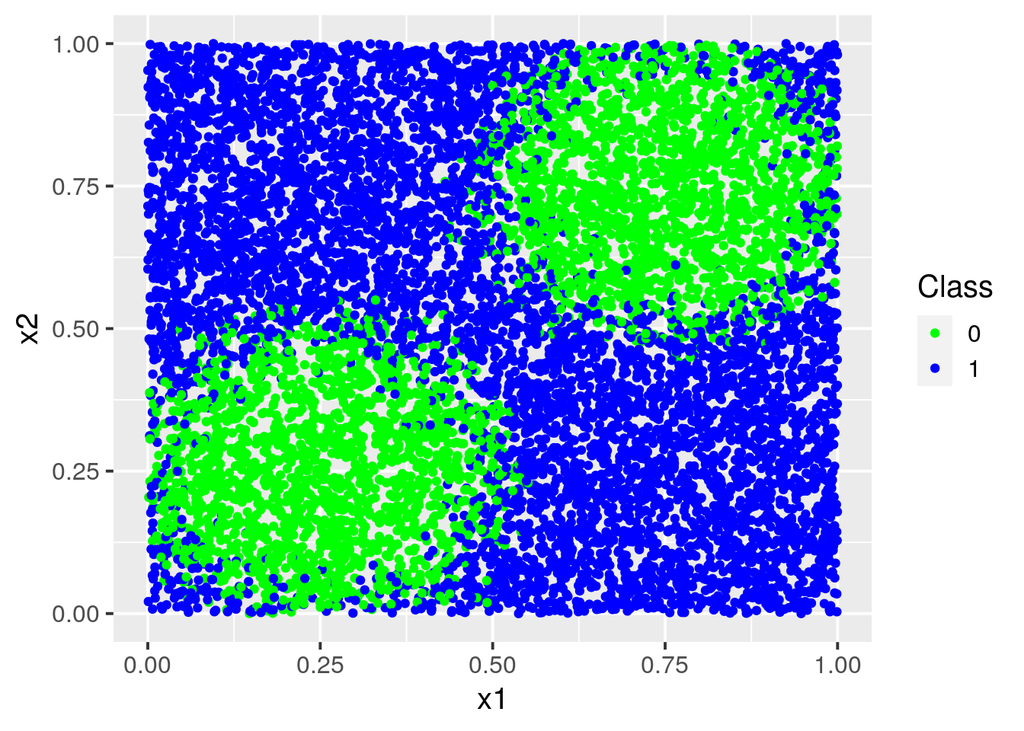

```r
df_data %>%
    ggplot(aes(x = x1 , y = x2, color =as.factor(y)))+
    geom_point()+
    scale_color_manual(name = 'Class',values = c('0'="green",'1'='blue'))+
    labs(linetype='')+
    theme_grey(base_size = 15)
```

```r
#print some summary statistics about these data
cat('Proportion of data in class blue: ' , sum(df_data$y)/length(df_data$y),'\n')
```

```
## Proportion of data in class blue:  0.6181
```

```r
cat('Proportion of data in class green: ' , 1-sum(df_data$y)/length(df_data$y),'\n')
```

```
## Proportion of data in class green:  0.3819
```

### Split into training and test set (Stratified split).

```r
# split with r sample and strata = y
split = initial_split(df_data, prop = 0.8, strata = 'y')

#train set
df_train = training(split)

#test set
df_test = testing(split)

#print statistics for each set
## training set
cat("Training set \n")
```

```
## Training set
```

```r
cat('Proportion of data in class blue: ' , sum(df_train$y)/length(df_train$y),'\n')
```

```
## Proportion of data in class blue:  0.6180477
```

```r
cat('Proportion of data in class green: ' , 1-sum(df_train$y)/length(df_train$y),'\n')
```

```
## Proportion of data in class green:  0.3819523
```

```r
##test set
cat("\nTest set \n")
```

```
##
## Test set
```

```r
cat('Proportion of data in class blue: ' , sum(df_test$y)/length(df_test$y),'\n')
```

```
## Proportion of data in class blue:  0.6183092
```

```r
cat('Proportion of data in class green: ' , 1-sum(df_test$y)/length(df_test$y),'\n')
```

```
## Proportion of data in class green:  0.3816908
```

### Create models

```r
#Learning rate
lr = 0.01
#Number of epochs
ne = 100
#Batch size
bs = 512

## functions for build and train NN
build_and_train_model = function (data = df_train,
                                  learning_rate = lr,
                                  num_epochs = ne,
                                  batch_size = bs,
                                  num_layers,
                                  num_units_per_layer,
                                  print_model_summary = F
                                 ){

    #Most models are so-called 'sequential' models
    model = keras_model_sequential()

    #Keras makes building neural networks as simple as adding layer upon layer with simple sequential
    #calls to the function "layer_dense". Take a moment to appreciate how easy that makes things.

    #The input layer is the only layer that requires the user to specify its shape. The shape of all
    #subsequent layers is automatically determined based on the output of the preceding layer. Let's
    #use a ReLU activation function in each node in the input and hidden layers.
    model = model %>% layer_dense(units=num_units_per_layer, input_shape=(ncol(data)-1), activation="relu")

    #Add the hidden layers. Note this requires just a simple for loop that calls the function "layer_dense"
    #again and again.
    if (num_layers>1){
        for (i in 1:(num_layers-1)){
            model = model %>% layer_dense(units=num_units_per_layer, activation="relu")
        }
    }

    #Add the output layer. Note that it uses a sigmoid activation function. Make sure you know why.
    model = model %>% layer_dense(units=1, activation="sigmoid")

    #Print the model description
    if (print_model_summary){

        summary(model)
    }

    #Specify the learning rate for stochastic gradient descent
    opt = optimizer_adam(lr = learning_rate)

    #Compile the model, using binary cross-entropy to define loss. Measure accuracy during training.
    #Note how easy Keras makes this. Did you have to write any functions for loss or for measuring model
    #performance during training? No, Keras takes care of all of this for you.
    model %>% compile(optimizer=opt, loss='binary_crossentropy', metrics= list('accuracy'))

    #Fit the model
    history = model %>% fit(x = as.matrix(data[,c('x1','x2')]),
                            y = data$y,
                            epochs=num_epochs,
                            batch_size=batch_size,
                            )

    #Return the model and the training history
    return(list(model = model, history = history))
}

## Build simplest model with 1 hidden layer of 2 nodes

c(model1,history1) %<-% build_and_train_model(data = df_train,
                                            learning_rate = 0.01,
                                            batch_size = 512,
                                            num_epochs = 100,
                                            num_layers = 1,
                                            num_units_per_layer =  2,
                                            print_model_summary = T)
```

```
## Model: "sequential"
## ________________________________________________________________________________
## Layer (type)                        Output Shape                    Param #
## ================================================================================
## dense (Dense)                       (None, 2)                       6
## ________________________________________________________________________________
## dense_1 (Dense)                     (None, 1)                       3
## ================================================================================
## Total params: 9
## Trainable params: 9
## Non-trainable params: 0
## ________________________________________________________________________________
```

```r
cat('Final training accuracy: ', round(history1$metrics$acc[ne],3),'\n')
```

```
## Final training accuracy:  0.692
```

```r
## Build second model with 3 hidden layer of 5 nodes

c(model2,history2) %<-% build_and_train_model(data = df_train,
                                            learning_rate = 0.01,
                                            batch_size = 512,
                                            num_epochs = 100,
                                            num_layers = 3,
                                            num_units_per_layer =  5,
                                            print_model_summary = T)
```

```
## Model: "sequential_1"
## ________________________________________________________________________________
## Layer (type)                        Output Shape                    Param #
## ================================================================================
## dense_2 (Dense)                     (None, 5)                       15
## ________________________________________________________________________________
## dense_3 (Dense)                     (None, 5)                       30
## ________________________________________________________________________________
## dense_4 (Dense)                     (None, 5)                       30
## ________________________________________________________________________________
## dense_5 (Dense)                     (None, 1)                       6
## ================================================================================
## Total params: 81
## Trainable params: 81
## Non-trainable params: 0
## ________________________________________________________________________________
```

```r
cat('Final training accuracy: ', round(history2$metrics$acc[ne],3),'\n')
```

```
## Final training accuracy:  0.894
```

```r
## Build second model with 5 hidden layer of 8 nodes

c(model3,history3) %<-% build_and_train_model(data = df_train,
                                            learning_rate = 0.01,
                                            batch_size = 512,
                                            num_epochs = 200,
                                            num_layers = 8,
                                            num_units_per_layer =  10,
                                            print_model_summary = T)
```

```
## Model: "sequential_2"
## ________________________________________________________________________________
## Layer (type)                        Output Shape                    Param #
## ================================================================================
## dense_6 (Dense)                     (None, 10)                      30
## ________________________________________________________________________________
## dense_7 (Dense)                     (None, 10)                      110
## ________________________________________________________________________________
## dense_8 (Dense)                     (None, 10)                      110
## ________________________________________________________________________________
## dense_9 (Dense)                     (None, 10)                      110
## ________________________________________________________________________________
## dense_10 (Dense)                    (None, 10)                      110
## ________________________________________________________________________________
## dense_11 (Dense)                    (None, 10)                      110
## ________________________________________________________________________________
## dense_12 (Dense)                    (None, 10)                      110
## ________________________________________________________________________________
## dense_13 (Dense)                    (None, 10)                      110
## ________________________________________________________________________________
## dense_14 (Dense)                    (None, 1)                       11
## ================================================================================
## Total params: 811
## Trainable params: 811
## Non-trainable params: 0
## ________________________________________________________________________________
```

```r
cat('Final training accuracy: ', round(history3$metrics$acc[ne],3),'\n')
```

```
## Final training accuracy:  0.913
```

### Calculate output and make decisions for each model on test set.

```r
#predict on test data
pred1 = predict(model1,as.matrix(df_test[,c('x1','x2')]))
pred2 = predict(model2,as.matrix(df_test[,c('x1','x2')]))
pred3 = predict(model3,as.matrix(df_test[,c('x1','x2')]))

#set the classification threshold
threshold = 0.5

#make predictions
y_pred1 = (pred1 >= threshold)*1
y_pred2 = (pred2 >= threshold)*1
y_pred3 = (pred3 >= threshold)*1
```

### Visualize test predictions for each model.

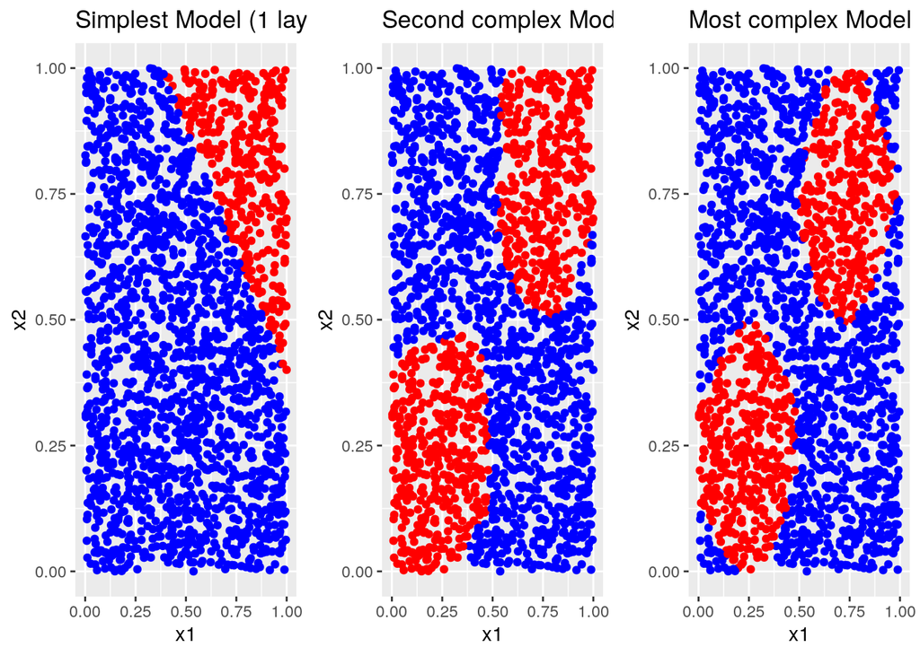

```r
#plot our predictions

p1 <- df_test %>%
        ggplot(aes(x = x1, y = x2))+
        geom_point(color = ifelse(y_pred1==1,'blue','red')) +
        ggtitle("Simplest Model (1 layer of 2 nodes)")

p2 <- df_test %>%
        ggplot(aes(x = x1, y = x2))+
        geom_point(color = ifelse(y_pred2==1,'blue','red')) +
        ggtitle("Second complex Model (3 layers of 5 nodes)")

p3 <- df_test %>%
        ggplot(aes(x = x1, y = x2))+
        geom_point(color = ifelse(y_pred3==1,'blue','red')) +
        ggtitle("Most complex Model (8 layers of 10 nodes)")

grid.arrange(p1, p2, p3, nrow = 1)
```

### Calculate metrics for each model on test set.

```r
#evaluate model performance on test data
c(loss1,acc1) %<-% evaluate(model1,as.matrix(df_test[,c('x1','x2')]),df_test$y)
c(loss2,acc2) %<-% evaluate(model2,as.matrix(df_test[,c('x1','x2')]),df_test$y)
c(loss3,acc3) %<-% evaluate(model3,as.matrix(df_test[,c('x1','x2')]),df_test$y)
cat('Accuracy of the simplest model on held-out test data: ' , round(acc1,3),'\n')
```

```
## Accuracy of the simplest model on held-out test data:  0.689
```

```r
cat('Accuracy of the second complex model on held-out test data: ' , round(acc2,3),'\n')
```

```
## Accuracy of the second complex model on held-out test data:  0.893
```

```r
cat('Accuracy of the most complex model on held-out test data: ' , round(acc3,3),'\n')
```

```
## Accuracy of the most complex model on held-out test data:  0.907
```

```r
#print precision,recall and F-score
c(true_positives, true_negatives,false_positives, false_negatives) %<-% confusion(df_test$y, pred1, threshold,verbose = F)
c(precision1, recall1) %<-% precision_and_recall(true_positives, true_negatives,false_positives, false_negatives)
```

```
## Precision:  0.6874237
## Recall:  0.9110032
```

```r
f1 = f_score(precision1,recall1)
```

```
## F-score:  0.7835769
```

```r
c(true_positives, true_negatives,false_positives, false_negatives) %<-% confusion(df_test$y, pred2, threshold,verbose = F)
c(precision2, recall2) %<-% precision_and_recall(true_positives, true_negatives,false_positives, false_negatives)
```

```
## Precision:  0.9286913
## Recall:  0.8956311
```

```r
f2 = f_score(precision2,recall2)
```

```
## F-score:  0.9118616
```

```r
c(true_positives, true_negatives,false_positives, false_negatives) %<-% confusion(df_test$y, pred3, threshold,verbose = F)
c(precision3, recall3) %<-% precision_and_recall(true_positives, true_negatives,false_positives, false_negatives)
```

```
## Precision:  0.9063467
## Recall:  0.947411
```

```r
f3 = f_score(precision3,recall3)
```

```
## F-score:  0.9264241
```

```r
## construct a metrix to store metrics
df_metrics <- data.frame(Model = c(1,2,3), Accuracy = c(acc1,acc2,acc3),
                         Precision = c(precision1,precision2,precision3),
                         Recall = c(recall1,recall2,recall3),
                         F_score = c(f1,f2,f3))
df_metrics # the best model is the most complex one
```

```
##   Model  Accuracy Precision    Recall   F_score
## 1     1 0.6888444 0.6874237 0.9110032 0.7835769
## 2     2 0.8929465 0.9286913 0.8956311 0.9118616
## 3     3 0.9069535 0.9063467 0.9474110 0.9264241
```

### Calculate ROC and AUC for the best model.

```r
#Consider 100 thresholds between 0 and 1
num_thresholds = 100
thresholds = seq(0,1,length.out = num_thresholds)

#Allocate space for the four metrics of the confusion matrix,
#as well as for precision and recall
fp = rep(NA,num_thresholds)
fn = rep(NA,num_thresholds)
tp = rep(NA,num_thresholds)
tn = rep(NA,num_thresholds)
precision = rep(NA,num_thresholds)
recall = rep(NA,num_thresholds)

#Loop over the thresholds, calculate the confusion matrix as well as precision and recall
for (i in 1:num_thresholds){

    c(tp[i], tn[i],fp[i], fn[i]) %<-% confusion(df_test$y, pred3, thresholds[i],verbose = F)
    c(precision[i], recall[i]) %<-% precision_and_recall(tp[i], tn[i],fp[i], fn[i],verbose = F)
    }

fpr = fp/(fp+tn)
auc = ROC(fpr, recall, viz = T)
cat('The AUC of the model3 with the best performance is:', round(auc$value,3))
```

```
## The AUC of the model3 with the best performance is: 0.973
```

### ROC Curve

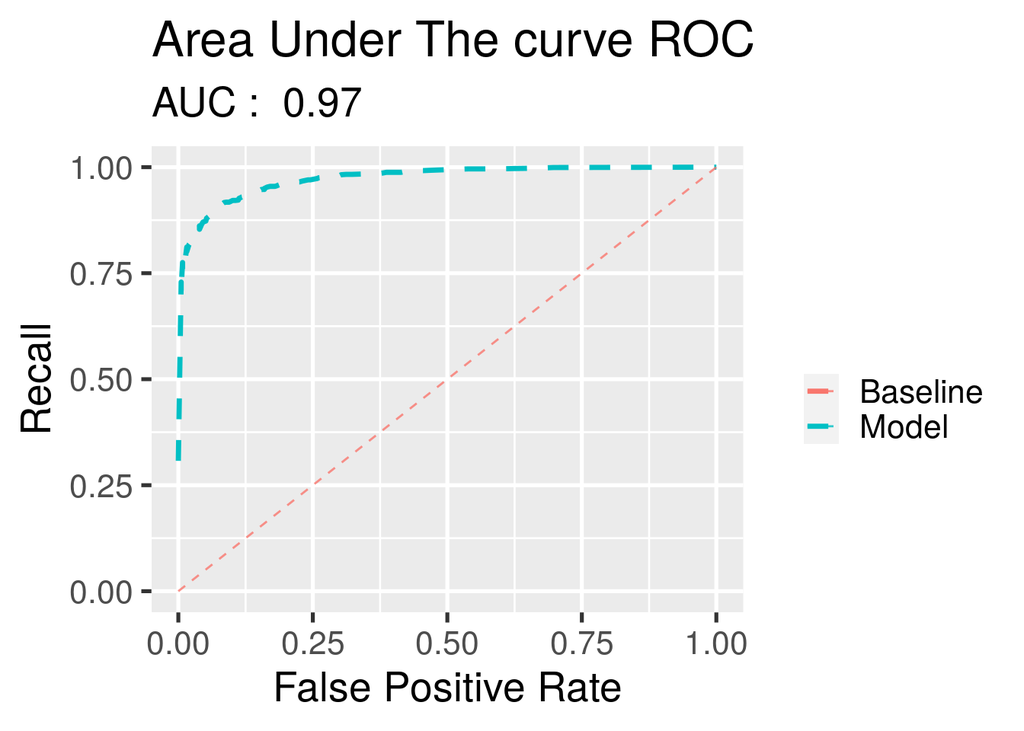

```r
auc$plot
```

### Train 5 times the best model, take probability outputs on test set for each time.

```r
num_initializations <- 5
pred = array(NA,dim = c(nrow(df_test),num_initializations))

for (k in 1:num_initializations){

        #Print some satisfying output
        message("You finish exercise quite fast today! Initialization " , as.character(k),'\n')

        #Build and train the model
        c(model, history) %<-% build_and_train_model(num_layers = 8,
                                                     num_units_per_layer = 10,
                                                     print_model_summary = F)

        #Predict on test data
        pred[,k] = predict(model,as.matrix(df_test[,c('x1','x2')]))

    }
```

```
## You finish exercise quite fast today! Initialization 1
```

```
## You finish exercise quite fast today! Initialization 2
```

```
## You finish exercise quite fast today! Initialization 3
```

```
## You finish exercise quite fast today! Initialization 4
```

```
## You finish exercise quite fast today! Initialization 5
```

### Average over the models output and then make decisions. Print Metrics.

```r
head(pred)
```

```
##           [,1]        [,2]       [,3]        [,4]       [,5]
## [1,] 0.8021740 0.719778419 0.81370342 0.802378535 0.71629071
## [2,] 0.0505794 0.009602904 0.01512221 0.004174292 0.01064551
## [3,] 0.9998180 0.998070657 0.99894381 0.999996305 0.99903584
## [4,] 0.9998784 0.999919653 0.99601382 0.999994040 0.99920392
## [5,] 1.0000000 1.000000000 1.00000000 1.000000000 0.99988735
## [6,] 0.8937937 0.749755263 0.90585095 0.946825445 0.90780902
```

```r
tail(pred)
```

```
##              [,1]       [,2]       [,3]        [,4]       [,5]
## [1994,] 0.8346345 0.70197439 0.82158577 0.837793052 0.75229609
## [1995,] 0.0505794 0.01709658 0.01512221 0.005696625 0.01344535
## [1996,] 0.8675051 0.81257606 0.84963107 0.874160230 0.90967298
## [1997,] 0.9998784 0.99998307 0.99999976 1.000000000 0.99986053
## [1998,] 0.3275230 0.27681652 0.39938700 0.312019795 0.30821696
## [1999,] 0.9998084 0.99516428 0.97897232 0.999186695 0.99245763
```

```r
str(pred)
```

```
##  num [1:1999, 1:5] 0.8022 0.0506 0.9998 0.9999 1 ...
```

```r
# average over the models
pred_average <- apply(pred,1,mean)
str(pred_average)
```

```
##  num [1:1999] 0.771 0.018 0.999 0.999 1 ...
```

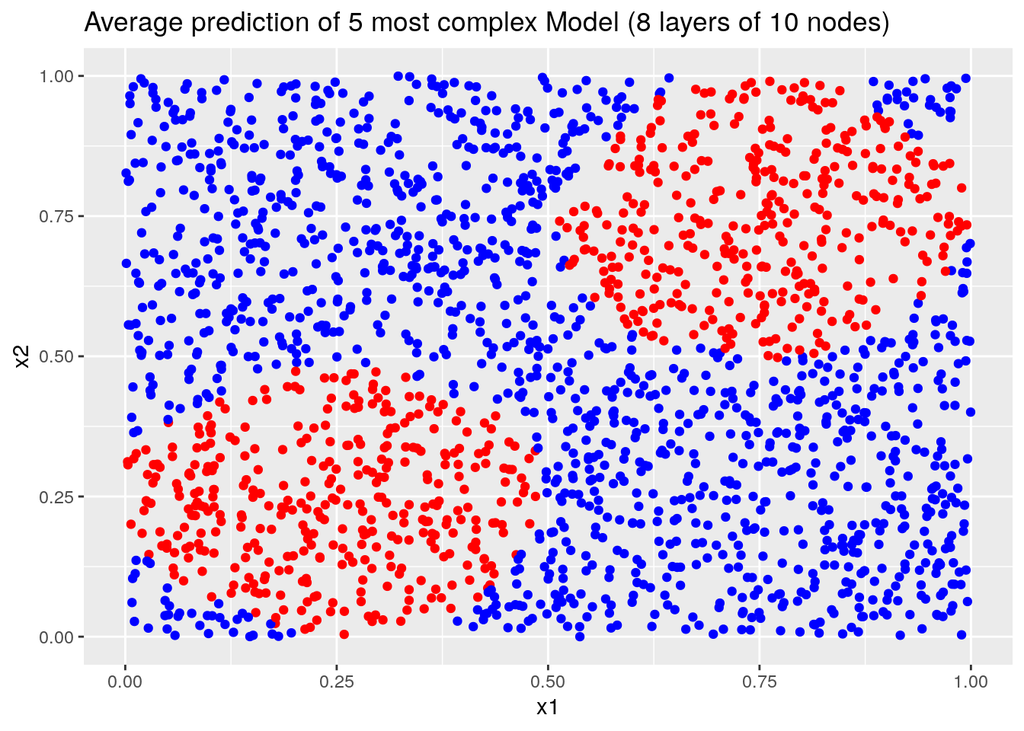

```r
# make decisions and calculate metrics
threshold <- 0.5
y_pred_final = (pred_average >= threshold)*1

# plot
df_test %>%
        ggplot(aes(x = x1, y = x2))+
        geom_point(color = ifelse(y_pred_final==1,'blue','red')) +
        ggtitle("Average prediction of 5 most complex Model (8 layers of 10 nodes)")
```

```r
# calculate metrics
#Evaluate model performance on test data
acc <- sum(y_pred_final == df_test$y)/nrow(df_test)
cat('Accuracy of the final model on held-out test data: ' , round(acc,3),'\n')
```

```
## Accuracy of the final model on held-out test data:  0.914
```

```r
#Print precision,recall and F-score
c(true_positives, true_negatives,false_positives, false_negatives) %<-% confusion(df_test$y, pred_average, threshold,verbose=F)
c(precision, recall) %<-% precision_and_recall(true_positives, true_negatives,false_positives, false_negatives)
```

```
## Precision:  0.9195584
## Recall:  0.9433657
```

```r
f = f_score(precision,recall)
```

```
## F-score:  0.9313099
```